**ANN with Regularization**

By Prof. Seungchul Lee  
http://iai.postech.ac.kr/  
Industrial AI Lab at POSTECH

Table of Contents

# 1. Overfitting Problem

- One of the most common problem data science professionals face is to avoid overfitting.
- Have you come across a situation where your model performed exceptionally well on train data, but was not able to predict test data.

[figure not shown]

## 1.1. Issue with Rich Representation

- Low error on input data points, but high error nearby
- Low error on training data, but high error on testing data
- Fundamental problem: we are optimizing parameters to solve

$$\min_{\omega} \sum \ell(h_{\omega} (x_i), y_i)$$

- But what we really care about is loss of prediction on new data $(x,y)$
  - also called generalization error

## 1.2. Different Regularization Techniques in Deep Learning

- $L_2$ and $L_1$ regularizations
- Data augmentation
  - The simplest way to reduce overfitting is to increase the size of the training data

[figure not shown]

- Early stopping
  - When we see that the performance on the validation set is getting worse, we immediately stop the training on the model

[figure not shown]

- Dropout
  - This is the one of the most interesting types of regularization techniques.
  - It also produces very good results and is consequently the most frequently used regularization technique in the field of deep learning.
  - At every iteration, it randomly selects some nodes and removes them.
  - It can also be thought of as an ensemble technique in machine learning.

[figure not shown]

## 1.3 Example

```python
import numpy as np
import matplotlib.pyplot as plt
import tensorflow as tf
```

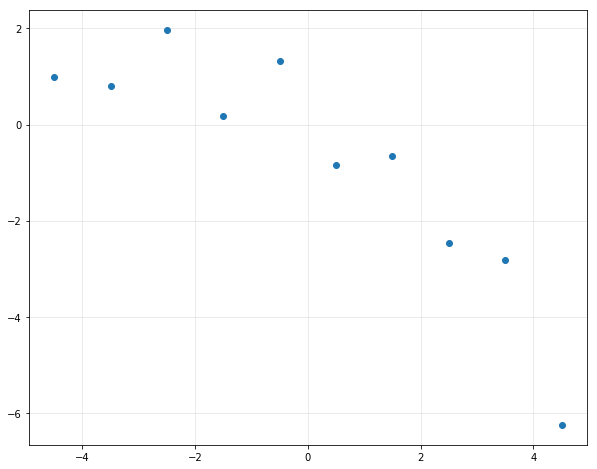

```python
N = 10
data_x = np.linspace(-4.5, 4.5, N)
data_y = np.array([0.9819, 0.7973, 1.9737, 0.1838, 1.3180, -0.8361, -0.6591, -2.4701, -2.8122, -6.2512])

data_x = data_x.reshape(-1,1)
data_y = data_y.reshape(-1,1)

plt.figure(figsize = (10,8))
plt.plot(data_x, data_y, 'o')
plt.grid(alpha = 0.3)
plt.show()
```

```python
n_input = 1
n_hidden1 = 30
n_hidden2 = 100
n_hidden3 = 100
n_hidden4 = 30
n_output = 1
```

```python
weights = {
    'hidden1' : tf.Variable(tf.random_normal([n_input, n_hidden1], stddev = 0.1)),
    'hidden2' : tf.Variable(tf.random_normal([n_hidden1, n_hidden2], stddev = 0.1)),
    'hidden3' : tf.Variable(tf.random_normal([n_hidden2, n_hidden3], stddev = 0.1)),
    'hidden4' : tf.Variable(tf.random_normal([n_hidden3, n_hidden4], stddev = 0.1)),
    'output' : tf.Variable(tf.random_normal([n_hidden4, n_output], stddev = 0.1)),
}

biases = {
    'hidden1' : tf.Variable(tf.random_normal([n_hidden1], stddev = 0.1)),
    'hidden2' : tf.Variable(tf.random_normal([n_hidden2], stddev = 0.1)),
    'hidden3' : tf.Variable(tf.random_normal([n_hidden3], stddev = 0.1)),
    'hidden4' : tf.Variable(tf.random_normal([n_hidden4], stddev = 0.1)),
    'output' : tf.Variable(tf.random_normal([n_output], stddev = 0.1)),
}

x = tf.placeholder(tf.float32, [None, n_input])
y = tf.placeholder(tf.float32, [None, n_output])
```

```python
def build_model(x, weights, biases):
    hidden1 = tf.add(tf.matmul(x, weights['hidden1']), biases['hidden1'])
    hidden1 = tf.nn.sigmoid(hidden1)

    hidden2 = tf.add(tf.matmul(hidden1, weights['hidden2']), biases['hidden2'])
    hidden2 = tf.nn.sigmoid(hidden2)

    hidden3 = tf.add(tf.matmul(hidden2, weights['hidden3']), biases['hidden3'])
    hidden3 = tf.nn.sigmoid(hidden3)

    hidden4 = tf.add(tf.matmul(hidden3, weights['hidden4']), biases['hidden4'])
    hidden4 = tf.nn.sigmoid(hidden4)

    output = tf.add(tf.matmul(hidden4, weights['output']), biases['output'])
    return output
```

```python
pred = build_model(x, weights, biases)
loss = tf.square(pred - y)
loss = tf.reduce_mean(loss)

LR = 0.001
optm = tf.train.AdamOptimizer(LR).minimize(loss)
```

```python
n_batch = 50
n_iter = 10000
n_prt = 1000

sess = tf.Session()
init = tf.global_variables_initializer()
sess.run(init)

loss_record = []

for epoch in range(n_iter):
    idx = np.random.randint(N, size = n_batch)
    train_x = data_x[idx,:]
    train_y = data_y[idx,:]

    sess.run(optm, feed_dict = {x: train_x,  y: train_y})

    if epoch % n_prt == 0:
        c = sess.run(loss, feed_dict = {x: train_x, y: train_y})
        loss_record.append(c)
        #print ("Iter : {}".format(epoch))
        #print ("Train Cost : {}".format(c))
```

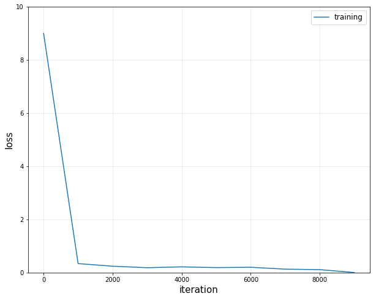

```python
plt.figure(figsize = (10,8))
plt.plot(np.arange(len(loss_record))*n_prt, loss_record, label = 'training')
plt.xlabel('iteration', fontsize = 15)
plt.ylabel('loss', fontsize = 15)
plt.grid(alpha = 0.3)
plt.legend(fontsize = 12)
plt.ylim([0, 10])
plt.show()
```

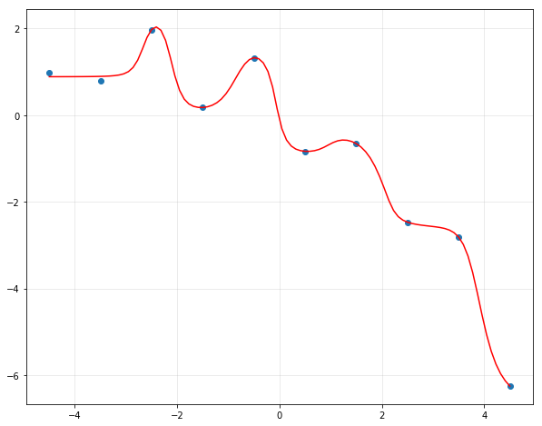

```python
xp = np.linspace(-4.5, 4.5, 100).reshape(-1,1)
my_pred = sess.run(pred, feed_dict = {x: xp})

plt.figure(figsize = (10,8))
plt.plot(data_x, data_y, 'o')
plt.plot(xp, my_pred, 'r')
plt.grid(alpha = 0.3)
plt.show()
```

# 2. Regularization (Shrinkage Methods)

Often, overfitting associated with very large estimated parameters $\omega$

We want to balance

- how well function fits data
- magnitude of coefficients
  $$ \begin{align*} \text{Total loss } = \;&\underbrace{\text{measure of fit}}_{RSS(\omega)} + \;\lambda \cdot \underbrace{\text{measure of magnitude of coefficients}}_{\lambda \cdot \lVert \omega \rVert_d} \\ \\ \implies &\min\; \lVert h_{\omega} (x_i) - y \rVert_2^2 + \lambda \lVert \omega \rVert_d \end{align*} $$
  where $ RSS(\omega) = \lVert h_{\omega} (x_i) - y \rVert^2_2 $, ( = Rresidual Sum of Squares) and $\lambda$ is a tuning parameter to be determined separately
- the second term, $\lambda \, \lVert \omega \rVert_d$, called a shrinkage penalty, is small when $\omega_1, \cdots,\omega_n$ are close to zeros, and so it has the effect of shrinking the estimates of $\omega_j$ towards zero
- The tuning parameter $\lambda$ serves to control the relative impact of these two terms on the weights' estimates

## 2.1. L2 Norm Regularizer

```python
lamb = 0.01

pred = build_model(x, weights, biases)
regularizer = tf.norm(weights['hidden1'], ord = 2) + \
              tf.norm(weights['hidden2'], ord = 2) + \
              tf.norm(weights['hidden3'], ord = 2) + \
              tf.norm(weights['hidden4'], ord = 2) + \
              tf.norm(weights['output'], ord = 2)

loss = tf.add(tf.square(pred - y), lamb*regularizer)
loss = tf.reduce_mean(loss)

LR = 0.0001
optm = tf.train.AdamOptimizer(LR).minimize(loss)
```

```python
n_batch = 50
n_iter = 10000
n_prt = 1000

sess = tf.Session()
init = tf.global_variables_initializer()
sess.run(init)
```

```python
loss_record = []

for epoch in range(n_iter):
    idx = np.random.randint(N, size = n_batch)
    train_x = data_x[idx,:]
    train_y = data_y[idx,:]

    sess.run(optm, feed_dict = {x: train_x,  y: train_y})

    if epoch % n_prt == 0:
        c = sess.run(loss, feed_dict = {x: train_x, y: train_y})
        loss_record.append(c)
        #print ("Iter : {}".format(epoch))
        #print ("Train Cost : {}".format(c))
```

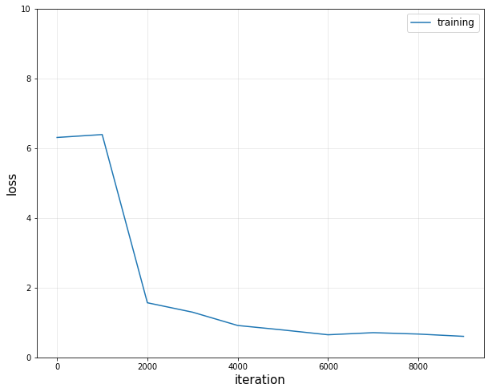

```python
plt.figure(figsize = (10,8))
plt.plot(np.arange(len(loss_record))*n_prt, loss_record, label = 'training')
plt.xlabel('iteration', fontsize = 15)
plt.ylabel('loss', fontsize = 15)
plt.grid('on', alpha = 0.3)
plt.legend(fontsize = 12)
plt.ylim([0, 10])
plt.show()
```

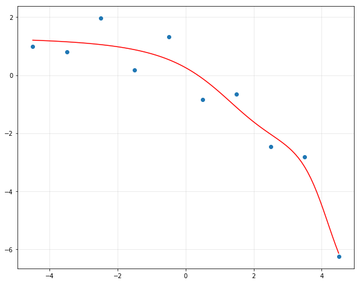

```python
xp = np.linspace(-4.5, 4.5, 100).reshape(-1,1)
my_pred = sess.run(pred, feed_dict = {x: xp})

plt.figure(figsize = (10,8))
plt.plot(data_x, data_y, 'o')
plt.plot(xp, my_pred, 'r')
plt.grid(alpha = 0.3)
plt.show()
```

## 2.2. L1 Norm Regularizer

```python
lamb = 0.0005

pred = build_model(x, weights, biases)
regularizer = tf.norm(weights['hidden1'], ord = 1) + \
              tf.norm(weights['hidden2'], ord = 1) + \
              tf.norm(weights['hidden3'], ord = 1) + \
              tf.norm(weights['hidden4'], ord = 1) + \
              tf.norm(weights['output'], ord = 1)

loss = tf.add(tf.square(pred - y), lamb*regularizer)
loss = tf.reduce_mean(loss)

LR = 0.0001
optm = tf.train.AdamOptimizer(LR).minimize(loss)
```

```python
n_batch = 50
n_iter = 10000
n_prt = 1000

sess = tf.Session()
init = tf.global_variables_initializer()
sess.run(init)
```

```python
loss_record = []

for epoch in range(n_iter):
    idx = np.random.randint(N, size = n_batch)
    train_x = data_x[idx,:]
    train_y = data_y[idx,:]

    sess.run(optm, feed_dict = {x: train_x,  y: train_y})

    if epoch % n_prt == 0:
        c = sess.run(loss, feed_dict = {x: train_x, y: train_y})
        loss_record.append(c)
        #print ("Iter : {}".format(epoch))
        #print ("Train Cost : {}".format(c))
```

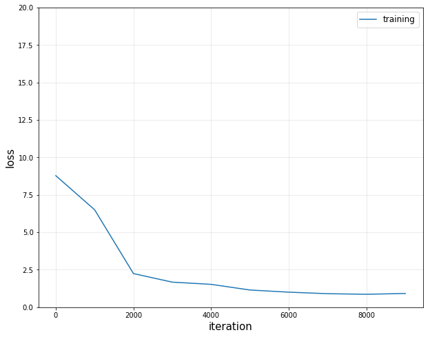

```python
plt.figure(figsize = (10,8))
plt.plot(np.arange(len(loss_record))*n_prt, loss_record, label = 'training')
plt.xlabel('iteration', fontsize = 15)
plt.ylabel('loss', fontsize = 15)
plt.grid('on', alpha = 0.3)
plt.legend(fontsize = 12)
plt.ylim([0, 20])
plt.show()
```

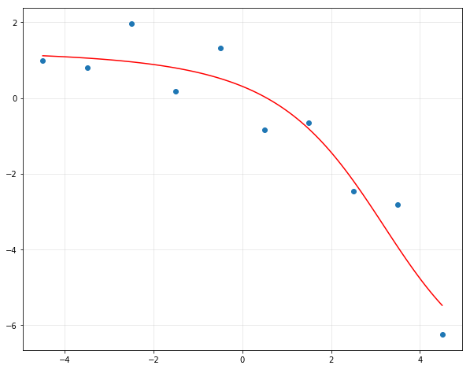

```python
xp = np.linspace(-4.5, 4.5, 100).reshape(-1,1)
my_pred = sess.run(pred, feed_dict = {x: xp})

plt.figure(figsize = (10,8))
plt.plot(data_x, data_y, 'o')
plt.plot(xp, my_pred, 'r')
plt.grid(alpha = 0.3)
plt.show()
```

# 3. Dropout

- This is the one of the most interesting types of regularization techniques.
- It also produces very good results and is consequently the most frequently used regularization technique in the field of deep learning.
- At every iteration, it randomly selects some nodes and removes them.
- It can also be thought of as an ensemble technique in machine learning.

[figure not shown]

```python
weights = {
    'hidden1' : tf.Variable(tf.random_normal([n_input, n_hidden1], stddev = 0.1)),
    'hidden2' : tf.Variable(tf.random_normal([n_hidden1, n_hidden2], stddev = 0.1)),
    'hidden3' : tf.Variable(tf.random_normal([n_hidden2, n_hidden3], stddev = 0.1)),
    'hidden4' : tf.Variable(tf.random_normal([n_hidden3, n_hidden4], stddev = 0.1)),
    'output' : tf.Variable(tf.random_normal([n_hidden4, n_output], stddev = 0.1)),
}

biases = {
    'hidden1' : tf.Variable(tf.random_normal([n_hidden1], stddev = 0.1)),
    'hidden2' : tf.Variable(tf.random_normal([n_hidden2], stddev = 0.1)),
    'hidden3' : tf.Variable(tf.random_normal([n_hidden3], stddev = 0.1)),
    'hidden4' : tf.Variable(tf.random_normal([n_hidden4], stddev = 0.1)),
    'output' : tf.Variable(tf.random_normal([n_output], stddev = 0.1)),
}

p = tf.placeholder(tf.float32)
x = tf.placeholder(tf.float32, [None, n_input])
y = tf.placeholder(tf.float32, [None, n_output])
```

```python
def build_model(x, weights, biases, p):
    hidden1 = tf.add(tf.matmul(x, weights['hidden1']), biases['hidden1'])
    hidden1 = tf.nn.sigmoid(hidden1)
    dropout1 = tf.nn.dropout(hidden1, keep_prob = p)

    hidden2 = tf.add(tf.matmul(dropout1, weights['hidden2']), biases['hidden2'])
    hidden2 = tf.nn.sigmoid(hidden2)
    dropout2 = tf.nn.dropout(hidden2, keep_prob = p)

    hidden3 = tf.add(tf.matmul(dropout2, weights['hidden3']), biases['hidden3'])
    hidden3 = tf.nn.sigmoid(hidden3)
    dropout3 = tf.nn.dropout(hidden3, keep_prob = p)

    hidden4 = tf.add(tf.matmul(dropout3, weights['hidden4']), biases['hidden4'])
    hidden4 = tf.nn.sigmoid(hidden4)
    dropout4 = tf.nn.dropout(hidden4, keep_prob = p)

    output = tf.add(tf.matmul(dropout4, weights['output']), biases['output'])
    return output
```

```python
pred = build_model(x, weights, biases, p)
loss = tf.square(pred - y)
loss = tf.reduce_mean(loss)

LR = 0.001
optm = tf.train.AdamOptimizer(LR).minimize(loss)
```

```python
n_batch = 50
n_iter = 10000
n_prt = 1000

sess = tf.Session()
init = tf.global_variables_initializer()
sess.run(init)

loss_record = []
for epoch in range(n_iter):
    idx = np.random.randint(N, size = n_batch)
    train_x = data_x[idx,:]
    train_y = data_y[idx,:]

    sess.run(optm, feed_dict = {x: train_x,  y: train_y, p: 0.2})

    if epoch % n_prt == 0:
        c = sess.run(loss, feed_dict = {x: train_x, y: train_y, p: 0.2})
        loss_record.append(c)
        #print ("Iter : {}".format(epoch))
        #print ("Train Cost : {}".format(c))
```

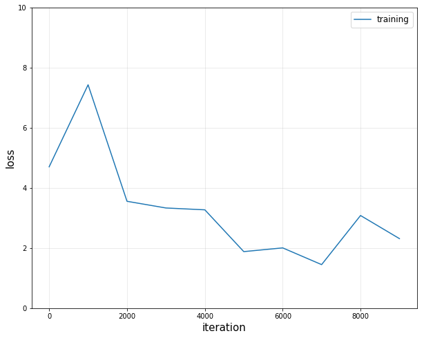

```python
plt.figure(figsize = (10,8))
plt.plot(np.arange(len(loss_record))*n_prt, loss_record, label = 'training')
plt.xlabel('iteration', fontsize = 15)
plt.ylabel('loss', fontsize = 15)
plt.grid('on', alpha = 0.3)
plt.legend(fontsize = 12)
plt.ylim([0, 10])
plt.show()
```

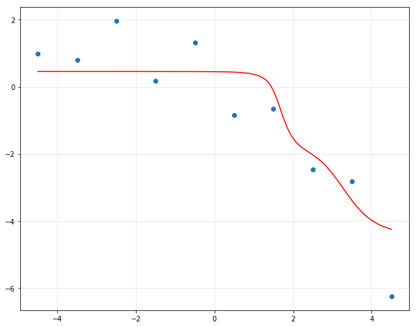

```python
xp = np.linspace(-4.5, 4.5, 100).reshape(-1,1)
my_pred = sess.run(pred, feed_dict = {x: xp, p: 1})

plt.figure(figsize = (10,8))
plt.plot(data_x, data_y, 'o')
plt.plot(xp, my_pred, 'r')
plt.grid(alpha = 0.3)
plt.show()
```

```python
%%javascript
$.getScript('https://kmahelona.github.io/ipython_notebook_goodies/ipython_notebook_toc.js')
```